# project

Shan

9/4/2020

```r
knitr::opts_chunk$set(echo = TRUE)
library(data.table)
library(tidyverse)
library(psych)
```

```r
library(leaflet)
library(ggplot2)
```

-Introduction: question: Among population with known race category, What’s the proportion of each race affected by the covid-19 across the U.S? which race was being affected most? (at each state, which race have the highest number positive cases and death cases? )

data background: the primary data source is the COVID Racial Data Tracker.They collect, cross-check, and publish COVID-19 data from 56 US states and territories in three main areas: testing, patient outcomes, and, via The COVID Racial Data Tracker, racial and ethnic demographic information. Data is being updated twice per week.

-Methods: Given the data being provied, we consider removing the NA’s. We sum up the case number of each race by the latest updated numbers, then summarized the proportion of races and ethnicity for both cases and deaths number across the States. The software would be R. #look at the data

```r
covid_race = data.table::fread("/Users/haoyueshan/Desktop/pm566/PM566-project/Race-Data.csv")
head(covid_race)
```

```
##        Date State Cases_Total Cases_White Cases_Black Cases_LatinX Cases_Asian
## 1: 20201007    AK        9861        3393         436           NA         436
## 2: 20201007    AL      161418       49446       34576           NA         569
## 3: 20201007    AR       88880       51550       18575           NA         977
## 4: 20201007    AS                                  NA           NA          NA
## 5: 20201007    AZ      222538       55918        6815        68182        2356
## 6: 20201007    CA      831225      100382       24802       355086       32359
##    Cases_AIAN Cases_NHPI Cases_Multiracial Cases_Other Cases_Unknown
## 1:       2028        475               393         372          2328
## 2:         NA         NA                NA       12023         64801
## 3:        234       2399               687        5688          8770
## 4:         NA         NA                NA          NA            NA
## 5:      12962         NA                NA        7287         69018
## 6:       1588       3151              6335       57848        249674
##    Cases_Ethnicity_Hispanic Cases_Ethnicity_NonHispanic Cases_Ethnicity_Unknown
```

[output cut: 34 more lines]

#choosing the latest data

```r
covid_race = covid_race[1:56,1:28]
tail(covid_race)
```

```
##        Date State Cases_Total Cases_White Cases_Black Cases_LatinX Cases_Asian
## 1: 20201007    VI        1322                      NA           NA          NA
## 2: 20201007    VT        1827        1507         197           NA          69
## 3: 20201007    WA       91208       24603        3632        25229        3062
## 4: 20201007    WI      146193      104296       12659           NA        3354
## 5: 20201007    WV       17139       13365         950           NA          NA
## 6: 20201007    WY        6899        3818          64          774          41
##    Cases_AIAN Cases_NHPI Cases_Multiracial Cases_Other Cases_Unknown
## 1:         NA         NA                NA          NA          1322
## 2:          2         NA                NA          40            12
## 3:       1013       1513              1615        1200         29341
## 4:       1703         NA                NA       10892         13289
## 5:          4         NA                NA        2820             0
## 6:        539         23                NA         310          1314
##    Cases_Ethnicity_Hispanic Cases_Ethnicity_NonHispanic Cases_Ethnicity_Unknown
```

[output cut: 34 more lines]

#change characteristic varibles into numeric varibles

```r
covid_race = covid_race %>%
  mutate(Cases_Total = as.numeric(Cases_Total), Cases_White = as.numeric(Cases_White), Cases_Ethnicity_Unknown = as.numeric(Cases_Ethnicity_Unknown))
covid_race
```

```
##         Date State Cases_Total Cases_White Cases_Black Cases_LatinX Cases_Asian
##  1: 20201007    AK        9861        3393         436           NA         436
##  2: 20201007    AL      161418       49446       34576           NA         569
##  3: 20201007    AR       88880       51550       18575           NA         977
##  4: 20201007    AS          NA          NA          NA           NA          NA
##  5: 20201007    AZ      222538       55918        6815        68182        2356
##  6: 20201007    CA      831225      100382       24802       355086       32359
##  7: 20201007    CO       74922       28597        3041        27698        1431
##  8: 20201007    CT       59364       20368        7501        11538         863
##  9: 20201007    DC       15697        3464        7893           NA         257
## 10: 20201007    DE       21550        8062        5695         4846         290
## 11: 20201007    FL      722707      189549      105597       208125          NA
## 12: 20201007    GA      326142      104291       85698        41976        5315
## 13: 20201007    GU        2868         257          NA           NA         588
## 14: 20201007    HI       13045        1115         174           NA        2611
```

[output cut: 391 more lines]

```r
sub = covid_race[,4:28]
sub
```

```
##     Cases_White Cases_Black Cases_LatinX Cases_Asian Cases_AIAN Cases_NHPI
##  1:        3393         436           NA         436       2028        475
##  2:       49446       34576           NA         569         NA         NA
##  3:       51550       18575           NA         977        234       2399
##  4:          NA          NA           NA          NA         NA         NA
##  5:       55918        6815        68182        2356      12962         NA
##  6:      100382       24802       355086       32359       1588       3151
##  7:       28597        3041        27698        1431        419        284
##  8:       20368        7501        11538         863         58         NA
##  9:        3464        7893           NA         257         38         43
## 10:        8062        5695         4846         290         NA         NA
## 11:      189549      105597       208125          NA         NA         NA
## 12:      104291       85698        41976        5315        183        299
## 13:         257          NA           NA         588         NA       1062
## 14:        1115         174           NA        2611         NA       3044
```

[output cut: 391 more lines]

#sum up the total values without NA’s for ecvery race and make an overall barplot

```r
temp = apply(sub,2,sum, na.rm = TRUE)
temp = as.data.frame(temp)
temp
```

```
##                                 temp
## Cases_White                  2247588
## Cases_Black                   859064
## Cases_LatinX                 1075970
## Cases_Asian                   132563
## Cases_AIAN                     58567
## Cases_NHPI                     18815
## Cases_Multiracial              33776
## Cases_Other                   379091
## Cases_Unknown                2721699
## Cases_Ethnicity_Hispanic     1347316
## Cases_Ethnicity_NonHispanic  2924516
## Cases_Ethnicity_Unknown      2681272
## Deaths_Total                  206925
## Deaths_White                  101679
## Deaths_Black                   40619
## Deaths_LatinX                  38044
## Deaths_Asian                    7215
## Deaths_AIAN                     1747
## Deaths_NHPI                      299
## Deaths_Multiracial               458
## Deaths_Other                    5936
## Deaths_Unknown                 10956
## Deaths_Ethnicity_Hispanic      40516
## Deaths_Ethnicity_NonHispanic  149988
## Deaths_Ethnicity_Unknown       14732
```

```r
names=rownames(temp)
names
```

```
##  [1] "Cases_White"                  "Cases_Black"
##  [3] "Cases_LatinX"                 "Cases_Asian"
##  [5] "Cases_AIAN"                   "Cases_NHPI"
##  [7] "Cases_Multiracial"            "Cases_Other"
##  [9] "Cases_Unknown"                "Cases_Ethnicity_Hispanic"
## [11] "Cases_Ethnicity_NonHispanic"  "Cases_Ethnicity_Unknown"
## [13] "Deaths_Total"                 "Deaths_White"
## [15] "Deaths_Black"                 "Deaths_LatinX"
## [17] "Deaths_Asian"                 "Deaths_AIAN"
## [19] "Deaths_NHPI"                  "Deaths_Multiracial"
## [21] "Deaths_Other"                 "Deaths_Unknown"
## [23] "Deaths_Ethnicity_Hispanic"    "Deaths_Ethnicity_NonHispanic"
## [25] "Deaths_Ethnicity_Unknown"
```

#make subgroup of cases and deaths

```r
cases_name = names[0:8]
cases_number= temp[0:8,]
cases = data.frame(cases_name,cases_number)
deaths_name = names[14:21]
deaths_number = temp[14:21,]
deaths = data.frame(deaths_name,deaths_number)
cases
```

```
##          cases_name cases_number
## 1       Cases_White      2247588
## 2       Cases_Black       859064
## 3      Cases_LatinX      1075970
## 4       Cases_Asian       132563
## 5        Cases_AIAN        58567
## 6        Cases_NHPI        18815
## 7 Cases_Multiracial        33776
## 8       Cases_Other       379091
```

```r
deaths
```

```
##          deaths_name deaths_number
## 1       Deaths_White        101679
## 2       Deaths_Black         40619
## 3      Deaths_LatinX         38044
## 4       Deaths_Asian          7215
## 5        Deaths_AIAN          1747
## 6        Deaths_NHPI           299
## 7 Deaths_Multiracial           458
## 8       Deaths_Other          5936
```

-Preliminary Results We got the latest number of case and death for each race group in the table above.

#count the percentage for each group

```r
pct_case = cases$cases_number/sum(cases$cases_number)
pct_cases = data.frame(cases_name,pct_case)
pct_cases
```

```
##          cases_name    pct_case
## 1       Cases_White 0.467718004
## 2       Cases_Black 0.178769285
## 3      Cases_LatinX 0.223906935
## 4       Cases_Asian 0.027586062
## 5        Cases_AIAN 0.012187661
## 6        Cases_NHPI 0.003915359
## 7 Cases_Multiracial 0.007028710
## 8       Cases_Other 0.078887984
```

```r
pct_death = deaths$deaths_number/sum(deaths$deaths_number)
pct_deaths = data.frame(deaths_name,pct_death)
pct_deaths
```

```
##          deaths_name   pct_death
## 1       Deaths_White 0.518778349
## 2       Deaths_Black 0.207242968
## 3      Deaths_LatinX 0.194105012
## 4       Deaths_Asian 0.036811788
## 5        Deaths_AIAN 0.008913402
## 6        Deaths_NHPI 0.001525534
## 7 Deaths_Multiracial 0.002336770
## 8       Deaths_Other 0.030286178
```

#making a pie chart for race compnent

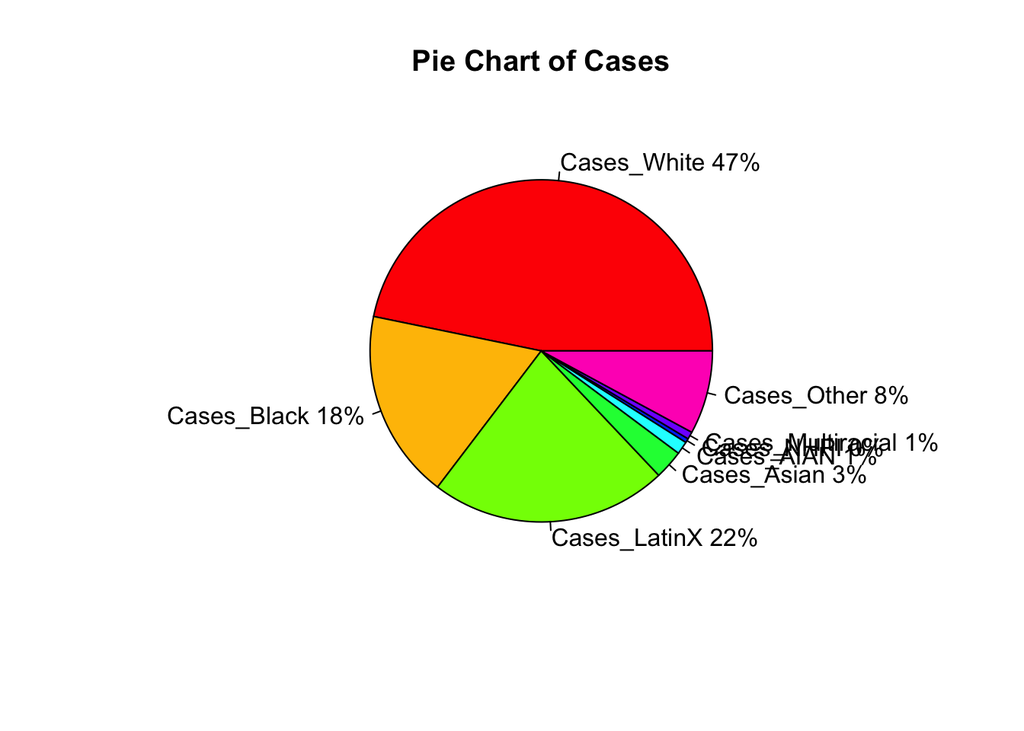

```r
slices = pct_case
lbls = cases_name
pct <- round(slices/sum(slices)*100)
lbls <- paste(lbls, pct) # add percents to labels
lbls <- paste(lbls,"%",sep="") # ad % to labels
pie(slices,labels = lbls, col=rainbow(length(lbls)),
   main="Pie Chart of Cases")
```

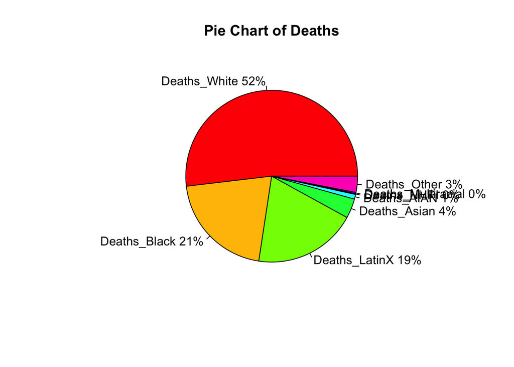

```r
slices = pct_death
lbls = deaths_name
pct <- round(slices/sum(slices)*100)
lbls <- paste(lbls, pct) # add percents to labels
lbls <- paste(lbls,"%",sep="") # ad % to labels
pie(slices,labels = lbls, col=rainbow(length(lbls)),
   main="Pie Chart of Deaths")
```

#make bar plot for each table（having troble adjusting the x-axis, fix it later)

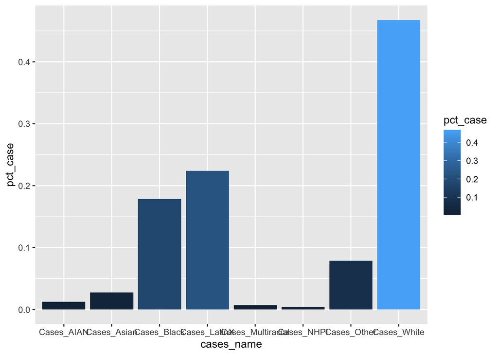

```r
  ggplot(data = pct_cases,aes(x=cases_name, y=pct_case, fill = pct_case))+
  geom_col()
```

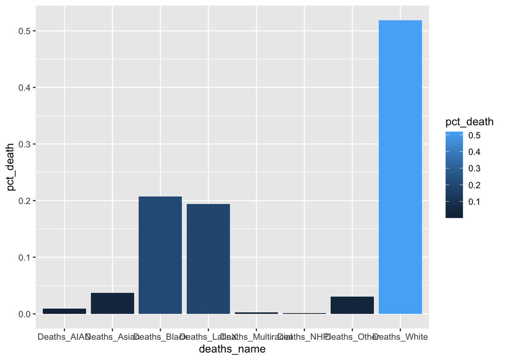

```r
 ggplot(data = pct_deaths,aes( x=deaths_name, y=pct_death, fill = pct_death))+
  geom_col()
```

4.conclusion Overall, among positive cases with known races, white, LatinX, and Black are the three most affected races; these three races also have the highest death number among known races’ death.